# pontos_cliente

Gabriel Moreira

2026-10-22

```r
arquivo_temp <- tempfile(fileext = ".R")

knitr::purl(
  "relatorio2.qmd",
  output = arquivo_temp,
  documentation = 0
)
```

[output not shown]

```
## [1] "C:\\Users\\gmore\\AppData\\Local\\Temp\\Rtmp6fzpTI\\file6fec57553669.R"
```

```r
sys.source(
  arquivo_temp,
  envir = knitr::knit_global()
)
```

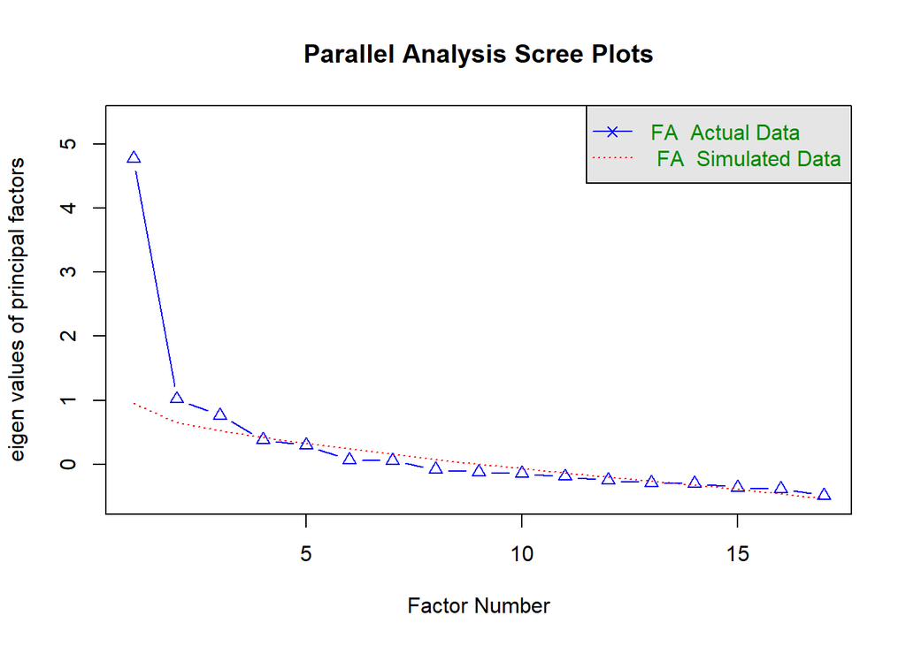

```
## Parallel analysis suggests that the number of factors =  3  and the number of components =  NA
```

```
##
## Loadings:
##                       MR4    MR3    MR1    MR2
## rec_caminhar           0.199  0.432  0.102
## rec_casal                     0.296
## rec_contemplar                0.312  0.335  0.184
## rec_treinamento        0.885
## rec_competicoes        0.920
## rec_comer_social                     0.569  0.102
## rec_redes_sociais     -0.113 -0.120  0.237  0.307
## rec_jogos_eletronicos                       0.555
## rec_filmes                                  0.675
## rec_academia           0.639  0.228
## rec_assistir_treinos   0.766
## rec_danca                     0.627
## rec_amigos                           0.858
## rec_desenhar                  0.473         0.320
## rec_musica                    0.816
## rec_jogos_mesa                0.320  0.202  0.331
## rec_religioso          0.236  0.427 -0.127
##
##                  MR4   MR3   MR1   MR2
## SS loadings    2.773 2.028 1.313 1.150
## Proportion Var 0.163 0.119 0.077 0.068
## Cumulative Var 0.163 0.282 0.360 0.427
##
## Loadings:
##                       MR1    MR5    MR4    MR3    MR2
## rec_caminhar           0.256  0.173  0.482
## rec_casal                     0.219  0.133
## rec_contemplar                       0.671  0.132
## rec_treinamento        0.894
## rec_competicoes        0.912
## rec_comer_social                            0.767
## rec_redes_sociais     -0.150                0.323  0.307
## rec_jogos_eletronicos                              0.568
## rec_filmes                                         0.649
## rec_academia           0.659  0.144  0.129
## rec_assistir_treinos   0.760
## rec_danca                     0.638
```

[output cut: 45 more lines]

```
## rec_jogos_eletronicos                      -0.111  0.602
## rec_filmes                   -0.114                0.683
## rec_academia           0.627  0.123  0.142
## rec_assistir_treinos   0.754                       0.113
## rec_danca                     0.678
## rec_amigos             0.110         0.290  0.664 -0.193
## rec_desenhar                  0.140  0.505         0.197
## rec_musica                    0.926               -0.224
## rec_jogos_mesa                0.203  0.233  0.145  0.226
## rec_religioso          0.158  0.672 -0.246
##
##                  MR1   MR3   MR5   MR2   MR4
## SS loadings    2.699 1.975 1.533 1.216 1.116
## Proportion Var 0.159 0.116 0.090 0.072 0.066
## Cumulative Var 0.159 0.275 0.365 0.437 0.502
```

```r
unlink(arquivo_temp)
rm(arquivo_temp)
```

1. Instituição fora dos modelos. Na Tabela 12, 63,7% dos estudantes da Javeriana estão em Flourishing, contra 23,2% da UFMG, e a Tabela 7 mostra diferenças entre as instituições em quase todos os itens. Queria entender se os resultados das práticas de lazer mudam quando a instituição entra no modelo. Também fiquei preocupada porque o Modelo 3 estima 30 coeficientes (um para cada característica incluída) e temos só 13 estudantes em Languishing. Queria entender se isso é suficiente para estimar tudo com segurança.

modelo2 - com universidade

| Variável | OR | 95% IC | Valor-p |
| --- | --- | --- | --- |
| idade | 0,76 | 0,60 – 0,96 | 0,022 |
| genero_modelo |  |  |  |
| Diversidade/múltiplas identidades | — | — |  |
| Homem cisgênero | 16,2 | 1,72 – 178 | 0,018 |
| Mulher cisgênero | 2,60 | 0,31 – 22,8 | 0,4 |
| trabalho_sim | 0,62 | 0,20 – 1,96 | 0,4 |
| horas_universidade_semana |  |  |  |
| +40h | — | — |  |
| 20 - 40h | 6,23 | 1,40 – 30,0 | 0,019 |
| Até 20h | 1,42 | 0,29 – 7,15 | 0,7 |
| rec_caminhar |  |  |  |
| 1-2 | — | — |  |
| 3-4 | 0,59 | 0,15 – 2,24 | 0,4 |
| 5-6 | 1,39 | 0,36 – 5,52 | 0,6 |
| 7-8 | 0,31 | 0,06 – 1,38 | 0,13 |
| 9-10 | 3,25 | 0,48 – 24,3 | 0,2 |
| rec_casal |  |  |  |
| 1-2 | — | — |  |
| 3-4 | 0,16 | 0,02 – 1,11 | 0,073 |
| 5-6 | 0,57 | 0,11 – 2,81 | 0,5 |
| 7-8 | 1,93 | 0,51 – 7,49 | 0,3 |
| 9-10 | 1,40 | 0,37 – 5,19 | 0,6 |
| rec_contemplar |  |  |  |
| 1-2 | — | — |  |
| 3-4 | 0,75 | 0,12 – 4,66 | 0,8 |
| 5-6 | 0,55 | 0,10 – 3,00 | 0,5 |
| 7-8 | 1,02 | 0,17 – 5,93 | >0,9 |
| 9-10 | 3,21 | 0,61 – 17,8 | 0,2 |
| rec_treinamento |  |  |  |
| 1-2 | — | — |  |

[output cut: 96 more lines]

Abreviações: IC = Intervalo de Confiança, OR = Razão de chances

modelo3 - com universidade

| Variável | OR | 95% IC | Valor-p |
| --- | --- | --- | --- |
| idade | 0,90 | 0,77 – 1,06 | 0,2 |
| genero_modelo |  |  |  |
| Diversidade/múltiplas identidades | — | — |  |
| Homem cisgênero | 6,28 | 1,19 – 33,9 | 0,031 |
| Mulher cisgênero | 2,15 | 0,43 – 10,7 | 0,3 |
| trabalho_sim | 0,81 | 0,36 – 1,80 | 0,6 |
| horas_universidade_semana |  |  |  |
| +40h | — | — |  |
| 20 - 40h | 2,32 | 0,77 – 6,96 | 0,13 |
| Até 20h | 1,53 | 0,50 – 4,62 | 0,5 |
| rec_caminhar | 1,04 | 0,90 – 1,20 | 0,6 |
| rec_casal | 1,07 | 0,97 – 1,18 | 0,2 |
| rec_contemplar | 1,12 | 0,98 – 1,28 | 0,10 |
| rec_treinamento | 1,03 | 0,89 – 1,19 | 0,7 |
| rec_competicoes | 0,96 | 0,82 – 1,13 | 0,6 |
| rec_comer_social | 1,04 | 0,90 – 1,20 | 0,6 |
| rec_redes_sociais | 1,05 | 0,92 – 1,20 | 0,4 |
| rec_jogos_eletronicos | 0,85 | 0,76 – 0,95 | 0,005 |
| rec_filmes | 1,13 | 1,01 – 1,25 | 0,029 |
| rec_academia | 1,05 | 0,91 – 1,22 | 0,5 |
| rec_assistir_treinos | 1,09 | 0,94 – 1,26 | 0,2 |
| rec_danca | 1,06 | 0,90 – 1,25 | 0,5 |
| rec_amigos | 1,01 | 0,86 – 1,20 | 0,9 |
| rec_desenhar | 0,98 | 0,86 – 1,12 | 0,8 |
| rec_musica | 1,01 | 0,82 – 1,23 | >0,9 |
| rec_jogos_mesa | 0,96 | 0,84 – 1,09 | 0,6 |
| rec_religioso | 0,98 | 0,84 – 1,15 | 0,8 |
| moradia_modelo |  |  |  |
| Família/parceiro(a) | — | — |  |
| Pares/coletivo | 0,54 | 0,19 – 1,53 | 0,3 |
| Sozinho(a) | 0,58 | 0,16 – 2,12 | 0,4 |
| etnia_cor_detalhada |  |  |  |
| Preta | — | — |  |
| Branca | 0,26 | 0,07 – 1,00 | 0,051 |
| Indígena | 0,14 | 0,00 – 13,1 | 0,4 |
| Nenhuma filiação étnica | 4,02 | 0,57 – 26,8 | 0,15 |
| Parda | 0,32 | 0,07 – 1,46 | 0,14 |
| anos_no_curso | 0,98 | 0,78 – 1,23 | 0,9 |
| contexto_institucional |  |  |  |
| Javeriana – Colômbia | — | — |  |
| UFMG – Brasil | 8,27 | 0,71 – 95,8 | 0,088 |

Abreviações: IC = Intervalo de Confiança, OR = Razão de chances

```
## modelo3 com uni
```

```
##                                GVIF Df GVIF^(1/(2*Df))
## idade                      1.988772  1        1.410238
## genero_modelo              1.889117  2        1.172370
## trabalho_sim               1.815550  1        1.347423
## horas_universidade_semana  1.351288  2        1.078169
## rec_caminhar               2.134868  1        1.461119
## rec_casal                  1.240456  1        1.113757
## rec_contemplar             1.795062  1        1.339799
## rec_treinamento            4.260063  1        2.063992
## rec_competicoes            5.333762  1        2.309494
## rec_comer_social           1.532583  1        1.237975
## rec_redes_sociais          1.295477  1        1.138190
## rec_jogos_eletronicos      1.627655  1        1.275796
## rec_filmes                 1.501352  1        1.225297
## rec_academia               2.815403  1        1.677916
## rec_assistir_treinos       3.057230  1        1.748494
## rec_danca                  1.982093  1        1.407868
## rec_amigos                 1.928824  1        1.388821
## rec_desenhar               1.569822  1        1.252926
## rec_musica                 2.399190  1        1.548932
## rec_jogos_mesa             1.665310  1        1.290469
## rec_religioso              1.511725  1        1.229522
## moradia_modelo             1.442655  2        1.095950
## etnia_cor_detalhada       20.375485  4        1.457600
## anos_no_curso              1.648240  1        1.283838
## contexto_institucional    18.341210  1        4.282664
```

```
## modelo3 sem uni
```

```
##                               GVIF Df GVIF^(1/(2*Df))
## idade                     1.913802  1        1.383402
## genero_modelo             1.823296  2        1.162022
## trabalho_sim              1.793550  1        1.339235
## horas_universidade_semana 1.347165  2        1.077346
## rec_caminhar              2.072905  1        1.439759
## rec_casal                 1.240352  1        1.113711
## rec_contemplar            1.795054  1        1.339796
## rec_treinamento           4.228289  1        2.056280
## rec_competicoes           5.216771  1        2.284025
## rec_comer_social          1.531377  1        1.237488
## rec_redes_sociais         1.292712  1        1.136975
## rec_jogos_eletronicos     1.617387  1        1.271765
## rec_filmes                1.498896  1        1.224294
## rec_academia              2.779323  1        1.667130
## rec_assistir_treinos      3.034630  1        1.742019
## rec_danca                 1.978413  1        1.406561
## rec_amigos                1.920106  1        1.385679
## rec_desenhar              1.569376  1        1.252747
## rec_musica                2.398953  1        1.548855
## rec_jogos_mesa            1.665079  1        1.290380
## rec_religioso             1.507347  1        1.227741
## moradia_modelo            1.434292  2        1.094358
## etnia_cor_detalhada       4.494458  4        1.206659
## anos_no_curso             1.646848  1        1.283296
```

```
## modelo2 com uni
```

```
##                                GVIF Df GVIF^(1/(2*Df))
## idade                      2.624414  1        1.620004
## genero_modelo              3.212923  2        1.338829
## trabalho_sim               2.517219  1        1.586575
## horas_universidade_semana  2.468104  2        1.253403
## rec_caminhar              10.785259  4        1.346182
## rec_casal                  5.102042  4        1.225937
## rec_contemplar             8.758559  4        1.311608
## rec_treinamento           32.410824  4        1.544672
## rec_competicoes           39.193056  4        1.581798
## rec_comer_social           8.440357  4        1.305555
## rec_redes_sociais          7.581993  4        1.288169
## rec_jogos_eletronicos      9.802143  4        1.330194
## rec_filmes                10.156031  4        1.336105
## rec_academia              22.752160  4        1.477841
## rec_assistir_treinos      17.264694  4        1.427726
## rec_danca                 25.181272  4        1.496700
## rec_amigos                 9.368847  4        1.322698
## rec_desenhar               9.154086  4        1.318870
## rec_musica                27.504092  4        1.513299
## rec_jogos_mesa             8.606732  4        1.308744
## rec_religioso              9.809927  4        1.330326
## moradia_modelo             2.623272  2        1.272655
## etnia_cor_detalhada       84.135831  4        1.740294
## anos_no_curso              2.047650  1        1.430961
## contexto_institucional    29.859798  1        5.464412
```

```
## modelo2 sem uni
```

```
##                                GVIF Df GVIF^(1/(2*Df))
## idade                      2.539053  1        1.593441
## genero_modelo              3.106493  2        1.327601
## trabalho_sim               2.507104  1        1.583384
## horas_universidade_semana  2.462272  2        1.252662
## rec_caminhar               9.931274  4        1.332372
## rec_casal                  5.024111  4        1.223580
## rec_contemplar             8.603219  4        1.308677
## rec_treinamento           31.956419  4        1.541948
## rec_competicoes           35.684194  4        1.563362
## rec_comer_social           8.270312  4        1.302238
## rec_redes_sociais          7.430077  4        1.284914
## rec_jogos_eletronicos      9.347161  4        1.322315
## rec_filmes                 9.973017  4        1.333071
## rec_academia              22.492468  4        1.475722
## rec_assistir_treinos      17.155765  4        1.426597
## rec_danca                 22.833408  4        1.478500
## rec_amigos                 9.323315  4        1.321893
## rec_desenhar               8.650446  4        1.309573
## rec_musica                23.794940  4        1.486143
## rec_jogos_mesa             8.202240  4        1.300893
## rec_religioso              9.120856  4        1.318270
## moradia_modelo             2.563276  2        1.265316
## etnia_cor_detalhada       17.704453  4        1.432222
## anos_no_curso              2.044978  1        1.430027
```

2. Verificações dos modelos. A Tabela 15 mostra só o número de parâmetros, o N e o AIC. Percebi que o AIC do Modelo 1 (336,0) é igual a 2 × 168, o que me fez pensar que esse modelo se ajustou perfeitamente aos dados por causa de separação. Gostaria de ver as demais verificações: convergência, gradiente, condição da Hessiana, GVIF, BIC e o teste de chances proporcionais.

Modelo 1 (original) — Regressão ordinal com cada nível da escala de lazer como categoria (referência: nível 1)

| Variável | OR | 95% IC | Valor-p |
| --- | --- | --- | --- |
| idade | 0,00 |  |  |
| genero_modelo |  |  |  |
| Diversidade/múltiplas identidades | — | — |  |
| Homem cisgênero | 21.473.172.544.420.994.842.264.420.260.260.802.860.220.460.640.200.840 |  |  |
| Mulher cisgênero | 124.815.669.233.504.662.064.266.006.264.448 |  |  |
| trabalho_sim | 14,3 |  |  |
| horas_universidade_semana |  |  |  |
| +40h | — | — |  |
| 20 - 40h | 53.197.712.848.906.144 |  |  |
| Até 20h | 5.159.165.043.899.988 |  |  |
| rec_caminhar |  |  |  |
| 1 | — | — |  |
| 2 | 0,00 |  |  |
| 3 | 0,00 |  |  |
| 4 | 1.751.517.431.534 |  |  |
| 5 | 0,00 |  |  |
| 6 | 0,57 |  |  |
| 7 | 0,00 |  |  |
| 8 | 0,00 |  |  |
| 9 | 0,00 |  |  |
| 10 | 0,00 |  |  |
| rec_casal |  |  |  |
| 1 | — | — |  |
| 2 | 3.278.164 |  |  |
| 3 | 12.750 |  |  |
| 4 | 247.875.098.609 |  |  |
| 5 | 715.863.049.923.104.000 |  |  |
| 6 | 38.514.445.173.186.292.098.622 |  |  |
| 7 | 0,00 |  |  |
| 8 | 0,00 |  |  |

[output cut: 178 more lines]

Abreviações: IC = Intervalo de Confiança, OR = Razão de chances

```
## Tests of nominal effects
##
## formula: mhc_classificacao ~ idade + genero_modelo + trabalho_sim + horas_universidade_semana + rec_caminhar + rec_casal + rec_contemplar + rec_treinamento + rec_competicoes + rec_comer_social + rec_redes_sociais + rec_jogos_eletronicos + rec_filmes + rec_academia + rec_assistir_treinos + rec_dan…
##                           Df  logLik    AIC     LRT  Pr(>Chi)
## <none>                       -110.06 386.11
## idade                      1 -109.38 386.76  1.3527 0.2448090
## genero_modelo              2 -109.13 388.26  1.8484 0.3968452
## trabalho_sim               1 -109.79 387.59  0.5284 0.4672912
## horas_universidade_semana  2 -109.30 388.61  1.5062 0.4708975
## rec_caminhar               4 -108.57 391.14  2.9756 0.5619213
## rec_casal                  4 -106.45 386.90  7.2124 0.1250799
## rec_contemplar             4 -106.98 387.97  6.1427 0.1887442
## rec_treinamento            4 -104.39 382.78 11.3297 0.0230982 *
## rec_competicoes            4 -101.28 376.57 17.5453 0.0015139 **
## rec_comer_social           4 -105.42 384.85  9.2629 0.0548530 .
## rec_redes_sociais          4 -106.89 387.79  6.3272 0.1760057
## rec_jogos_eletronicos      4 -107.14 388.27  5.8395 0.2114570
## rec_filmes                 4 -103.67 381.34 12.7717 0.0124470 *
## rec_academia               4 -109.37 392.75  1.3660 0.8500755
## rec_assistir_treinos       4 -108.91 391.82  2.2906 0.6824863
## rec_danca                  4 -106.70 387.40  6.7121 0.1519069
## rec_amigos                 4 -100.26 374.53 19.5870 0.0006024 ***
## rec_desenhar               4 -107.74 389.48  4.6311 0.3272873
## rec_musica                 4 -108.21 390.42  3.6924 0.4492286
## rec_jogos_mesa             4 -107.00 388.01  6.1050 0.1914462
## rec_religioso              4 -107.36 388.71  5.3989 0.2487595
## moradia_modelo             2 -107.24 384.48  5.6312 0.0598683 .
## etnia_cor_detalhada        4 -105.22 384.45  9.6656 0.0464532 *
## anos_no_curso              1 -109.99 387.98  0.1317 0.7166976
## ---
## Signif. codes:  0 '***' 0.001 '**' 0.01 '*' 0.05 '.' 0.1 ' ' 1
```

```
## Tests of nominal effects
##
## formula: mhc_classificacao ~ idade + genero_modelo + trabalho_sim + horas_universidade_semana + rec_caminhar + rec_casal + rec_contemplar + rec_treinamento + rec_competicoes + rec_comer_social + rec_redes_sociais + rec_jogos_eletronicos + rec_filmes + rec_academia + rec_assistir_treinos + rec_dan…
##                           Df  logLik    AIC    LRT Pr(>Chi)
## <none>                       -150.54 365.07
## idade                      1 -149.99 365.98 1.0921  0.29601
## genero_modelo              2 -148.25 364.49 4.5840  0.10106
## trabalho_sim               1 -150.54 367.07 0.0009  0.97594
## horas_universidade_semana  2 -149.14 366.28 2.7974  0.24691
## rec_caminhar               1 -150.53 367.05 0.0210  0.88479
## rec_casal                  1 -149.64 365.29 1.7867  0.18133
## rec_contemplar             1 -150.43 366.85 0.2226  0.63710
## rec_treinamento            1 -148.96 363.91 3.1630  0.07533 .
## rec_competicoes            1 -149.22 364.43 2.6438  0.10395
## rec_comer_social           1 -149.45 364.90 2.1716  0.14058
## rec_redes_sociais          1 -150.38 366.75 0.3232  0.56967
## rec_jogos_eletronicos      1 -150.30 366.60 0.4730  0.49162
## rec_filmes                 1 -150.19 366.37 0.7037  0.40155
## rec_academia               1 -150.33 366.66 0.4111  0.52142
## rec_assistir_treinos       1 -149.52 365.05 2.0257  0.15466
## rec_danca                  1 -150.52 367.05 0.0247  0.87521
## rec_amigos                 1 -147.52 361.04 6.0360  0.01402 *
## rec_desenhar               1 -150.42 366.84 0.2368  0.62652
## rec_musica
## rec_jogos_mesa             1 -150.48 366.96 0.1104  0.73966
## rec_religioso              1 -150.12 366.24 0.8372  0.36021
## moradia_modelo             2 -148.39 364.78 4.2965  0.11669
## etnia_cor_detalhada        4 -147.95 367.91 5.1661  0.27068
## anos_no_curso              1 -150.51 367.03 0.0473  0.82775
## ---
## Signif. codes:  0 '***' 0.001 '**' 0.01 '*' 0.05 '.' 0.1 ' ' 1
```

```
##
##               1-2 3-4 5-6 7-8 9-10
##   Languishing   9   1   2   1    0
##   Moderate     54   6   3  16   41
##   Flourishing  18   3   6   9   58
```

```
##
##               1-2 3-4 5-6 7-8 9-10
##   Languishing  10   0   3   0    0
##   Moderate     60   6   3  16   35
##   Flourishing  20   5   6   7   56
```

```
##
##               1-2 3-4 5-6 7-8 9-10
##   Languishing   6   0   1   3    3
##   Moderate     32  14  13  26   35
##   Flourishing  21   3  10  22   38
```

```
##
##               1-2 3-4 5-6 7-8 9-10
##   Languishing   0   2   2   2    7
##   Moderate      8  15  12  31   54
##   Flourishing   0   2   7  19   66
```

```
##
##               Preta Branca Indígena Nenhuma filiação étnica Parda
##   Languishing     0     10        0                       1     2
##   Moderate       11     51        1                      32    25
##   Flourishing     8     18        1                      61     6
```

3. Tabela 7 (Mann-Whitney). Alguns itens aparecem como significativos mesmo com medianas iguais (por exemplo, sm_interesse: 5 e 5), e foram feitos 34 testes sem ajuste. Queria ver o tamanho do efeito (W / n1 × n2) e os p-valores ajustados (Holm e Benjamini-Hochberg), para saber quais diferenças realmente se sustentam.
4. Shapiro-Wilk (Tabela 8). Vi que o teste foi aplicado também à amostra total, e queria entender se isso faz sentido para comparar as instituições. Gostaria de ver o teste por grupo, com gráficos Q-Q.
5. Intervalos de confiança do texto. Na seção 5.4, o texto traz para rec_casal (faixa 3-4) um intervalo de 0,66 a 1,11, mas a Tabela 13 mostra 0,02 a 1,01. Na seção 5.5, o texto traz 0,79 a 0,99 para jogos eletrônicos, filmes e contemplar, e a Tabela 14 mostra 0,77 a 0,96, 1,01 a 1,24 e 0,98 a 1,28. Você consegue me ajudar a ligar os números do texto às tabelas por código, para os dois sempre coincidirem?